# Project: Wrangle and Analyze WeRateDogs Tweets

*Muthukumar Palavesam*

- Introduction
- Gathering Data
  - Direct CSV File download
  - Using `requests` library in python
  - Extract the data from twitter using `tweepy` library in python
- Assessment Of Data
- Assessment Summary
- Cleaning the Data
  - Quality
  - Tidiness
- Storing the cleaned Dataset
- Analyzing and Visualizing
- Conclusions
- Resources I used in my analysis

## Introduction

In this Project I will be wrangling (and analyzing and visualizing) is the tweet archive of Twitter user `@dog_rates`, also known as WeRateDogs. `WeRateDogs` is a Twitter account that rates people's dogs with a humorous comment about the dog. These ratings almost always have a denominator of 10. The numerators, though? Almost always greater than 10. 11/10, 12/10, 13/10, etc. Why? Because "they're good dogs Brent." WeRateDogs has over 4 million followers and has received international media coverage.

```python
#import the necessary package for this project
import pandas as pd
import numpy as np
import requests
import tweepy
import json
import matplotlib.pyplot as plt
from timeit import default_timer as timer
from datetime import datetime
import re
from IPython.display import display, HTML,Markdown,Image
#https://stackoverflow.com/questions/47022070/display-all-dataframe-columns-in-a-jupyter-python-notebook
#pd.get_option("display.max_rows")
pd.set_option('display.max_columns', None)
pd.set_option('display.max_rows', None)
pd.set_option('display.max_colwidth', 500)
import seaborn as sns
sns.set_style("whitegrid")
import tab
%matplotlib inline
```

###### script to print the dataframe borders [Ref Link](https://stackoverflow.com/questions/49888173/python-jupyter-notebook-print-dataframe-borders/51858584)

```python
%%HTML
<style type="text/css">
table.dataframe td, table.dataframe th {
    border: 0.5px  black solid !important;
  color: black !important;
}
</style>
```

###### Script to Show the embed tweets in Jupyter notebooks [Ref Link](https://github.com/jupyter/notebook/issues/2790)

```python
class Tweet(object):
    def __init__(self, embed_str=None):
        self.embed_str = embed_str

    def _repr_html_(self):
        return self.embed_str
```

## Gathering Data

In this section we need to gather three pieces of data as described below

- Direct `CSV File` download
- Using `requests` library in python
- Extract the data from twitter using `tweepy` library in python

###### (i) Gathering Data : Direct `CSV File` download

The WeRateDogs Twitter archive. As per Udacity, Downloading the CSV file manually by clicking the following link: [twitter_archive_enhanced.csv](https://d17h27t6h515a5.cloudfront.net/topher/2017/August/59a4e958_twitter-archive-enhanced/twitter-archive-enhanced.csv). Once downloaded, I copyied this file into my local project folder.

```python
#Read the CSV file using pandas "read_csv" function
tweet_archieve=pd.read_csv('twitter-archive-enhanced.csv')
```

###### (ii) Gathering Data : Using `requests` library in python

This file (image_predictions.tsv) is hosted on Udacity's servers and should be downloaded programmatically using the Requests library and the following URL: https://d17h27t6h515a5.cloudfront.net/topher/2017/August/599fd2ad_image-predictions/image-predictions.tsv

```python
#Downloading `image_predictions.tsv` File using `requests library` in python
url = 'https://d17h27t6h515a5.cloudfront.net/topher/2017/August/599fd2ad_image-predictions/image-predictions.tsv'
r = requests.get(url)
with open('image_predictions.tsv', mode='wb') as file:
    file.write(r.content)
```

```python
#Read the CSV file using pandas "read_csv" function
img_predict=pd.read_csv('image_predictions.tsv',sep='\t')
```

###### (iii) Gathering Data :Extract the data from twitter using `tweepy` library in python

Using the tweet IDs in the WeRateDogs Twitter archive, query the Twitter API for each tweet's JSON data using Python's `Tweepy` library and store each tweet's entire set of JSON data in a file called `tweet_json.txt` file. Each tweet's JSON data should be written to its own line. Then read this .txt file line by line into a pandas DataFrame with (at minimum) tweet ID, retweet count, and favorite count.

```python
consumer_key = '*********************'
consumer_secret = '***********************'
access_token = '****************************'
access_secret = '**************************'

auth = tweepy.OAuthHandler(consumer_key, consumer_secret)
auth.set_access_token(access_token, access_secret)

api = tweepy.API(auth,wait_on_rate_limit=True,wait_on_rate_limit_notify=True)
```

```python
count = 0
fails_dict = {}
start = timer()
# Save each tweet's returned JSON as a new line in a .txt file
with open('tweet_json.txt', 'w') as outfile:
    # This loop will likely take 20-30 minutes to run because of Twitter's rate limit
    for tweet_id in tweet_ids:
        count += 1
        print(str(count) + ": " + str(tweet_id))
        try:
            tweet = api.get_status(tweet_id, tweet_mode='extended')
            print("Success")
            json.dump(tweet._json, outfile)
            outfile.write('\n')
        except tweepy.TweepError as e:
            print("Fail")
            fails_dict[tweet_id] = e
            pass
end = timer()
print(end - start)
print(fails_dict)
```

[output not shown]

[output cut: 1744 more lines]

[output not shown]

```
Rate limit reached. Sleeping for: 739
```

[output not shown]

[output cut: 1747 more lines]

[output not shown]

```
Rate limit reached. Sleeping for: 734
```

[output not shown]

[output cut: 1058 more lines]

[output not shown]

```python
#reading the text file and store it into `tweets_data`
tweets_data = pd.DataFrame(columns = ['tweet_id','favorites','retweets'])
with open('tweet_json.txt') as json_file:
    for line in json_file:
        tweet = json.loads(line)
        tweets_data = tweets_data.append({'tweet_id': tweet['id'],'favorites': tweet['favorite_count']
                                      ,'retweets': tweet['retweet_count']}, ignore_index=True)
```

```python
#Saving the gathered data into CSV format in my local folder.So that I can read it via Excel to look into the dats
img_predict.to_csv('img_predict.csv',index=False)
tweets_data.to_csv('tweets_data.csv',index=False)
```

## Assessment Of Data

After gathering each of the above pieces of data, assess them visually and programmatically for quality and tidiness issues. Detect and document at least *`eight (8) quality issues and two (2) tidiness issues`* in your *`wrangle_act.ipynb`* Jupyter Notebook. To meet specifications, the issues that satisfy the Project Motivation (see the Key Points header on the previous page) must be assessed.

So Now I have Three datasets

> - tweet_archieve (WeRateDogs Twitter archive)
> - img_predict (Image predictions)
> - tweets_data (Additional data on the tweets gathered from twitter API)

```python
#Checking the column name and comparing with each others whether I can merge it or not
display(Markdown('**`tweet_archieve` Columns**'))
print(list(tweet_archieve.columns))
display(Markdown('**`img_predict` Columns**'))
print(list(img_predict.columns))
display(Markdown('**`tweets_data` Columns**'))
print(list(tweets_data.columns))
```

**`tweet_archieve` Columns**

```
['tweet_id', 'in_reply_to_status_id', 'in_reply_to_user_id', 'timestamp', 'source', 'text', 'retweeted_status_id', 'retweeted_status_user_id', 'retweeted_status_timestamp', 'expanded_urls', 'rating_numerator', 'rating_denominator', 'name', 'doggo', 'floofer', 'pupper', 'puppo']
```

**`img_predict` Columns**

```
['tweet_id', 'jpg_url', 'img_num', 'p1', 'p1_conf', 'p1_dog', 'p2', 'p2_conf', 'p2_dog', 'p3', 'p3_conf', 'p3_dog']
```

**`tweets_data` Columns**

```
['tweet_id', 'favorites', 'retweets']
```

-'tweet_id' column is common in each datset. So joining the tables are possible

```python
#Checking the number of rows in each dataset using shape function
display(Markdown('**Result :**'))
print("No of Rows in 'tweet_archieve' dataset = {}".format(tweet_archieve.shape[0]))
print("No of Rows in 'img_predict' dataset = {}".format(img_predict.shape[0]))
print("No of Rows in 'tweets_data' dataset = {}".format(tweets_data.shape[0]))
```

**Result :**

```
No of Rows in 'tweet_archieve' dataset = 2356
No of Rows in 'img_predict' dataset = 2075
No of Rows in 'tweets_data' dataset = 2337
```

- Tables do not contain the same number of entries.

###### Exploring `tweet_archieve` Datset:

```python
# Using info() function to get a concise summary of tweet_archieve
tweet_archieve.info()
```

```
<class 'pandas.core.frame.DataFrame'>
RangeIndex: 2356 entries, 0 to 2355
Data columns (total 17 columns):
tweet_id                      2356 non-null int64
in_reply_to_status_id         78 non-null float64
in_reply_to_user_id           78 non-null float64
timestamp                     2356 non-null object
source                        2356 non-null object
text                          2356 non-null object
retweeted_status_id           181 non-null float64
retweeted_status_user_id      181 non-null float64
retweeted_status_timestamp    181 non-null object
expanded_urls                 2297 non-null object
rating_numerator              2356 non-null int64
rating_denominator            2356 non-null int64
name                          2356 non-null object
doggo                         2356 non-null object
floofer                       2356 non-null object
pupper                        2356 non-null object
puppo                         2356 non-null object
dtypes: float64(4), int64(3), object(10)
memory usage: 313.0+ KB
```

- **tweet_id** should be string  
- **timestamp** columns showing as object (ie. str)

```python
# Printing few lines of tweet_archieve data using head function
tweet_archieve.head(3)
```

|  | tweet_id | in_reply_to_status_id | in_reply_to_user_id | timestamp | source | text | retweeted_status_id | retweeted_status_user_id | retweeted_status_timestamp | expanded_urls | rating_numerator | rating_denominator | name | doggo | floofer | pupper | puppo |
| --- | --- | --- | --- | --- | --- | --- | --- | --- | --- | --- | --- | --- | --- | --- | --- | --- | --- |
| 0 | 892420643555336193 | NaN | NaN | 2017-08-01 16:23:56 +0000 | <a href="http://twitter.com/download/iphone" rel="nofollow">Twitter for iPhone</a> | This is Phineas. He's a mystical boy. Only ever appears in the hole of a donut. 13/10 https://t.co/MgUWQ76dJU | NaN | NaN | NaN | https://twitter.com/dog_rates/status/892420643555336193/photo/1 | 13 | 10 | Phineas | None | None | None | None |
| 1 | 892177421306343426 | NaN | NaN | 2017-08-01 00:17:27 +0000 | <a href="http://twitter.com/download/iphone" rel="nofollow">Twitter for iPhone</a> | This is Tilly. She's just checking pup on you. Hopes you're doing ok. If not, she's available for pats, snugs, boops, the whole bit. 13/10 https://t.co/0Xxu71qeIV | NaN | NaN | NaN | https://twitter.com/dog_rates/status/892177421306343426/photo/1 | 13 | 10 | Tilly | None | None | None | None |
| 2 | 891815181378084864 | NaN | NaN | 2017-07-31 00:18:03 +0000 | <a href="http://twitter.com/download/iphone" rel="nofollow">Twitter for iPhone</a> | This is Archie. He is a rare Norwegian Pouncing Corgo. Lives in the tall grass. You never know when one may strike. 12/10 https://t.co/wUnZnhtVJB | NaN | NaN | NaN | https://twitter.com/dog_rates/status/891815181378084864/photo/1 | 12 | 10 | Archie | None | None | None | None |

- **source** column is lengthy and unwanted HTML tag is there  
- tweet **text** column is showing with URL.  
- doggo, floofer, pupper and puppo columns in tweet_archieve table should be merged into one column named **stage**

```python
#Fetching the unique value for the column `name` and finding the bad dog names
dog_nam=tweet_archieve['name'].unique()
dog_nam.sort()
#https://stackoverflow.com/questions/14875248/python-numpy-sort-array/24996734
dog_nam = dog_nam[::-1]
print(dog_nam)
```

```
['very' 'unacceptable' 'this' 'the' 'such' 'space' 'quite' 'one' 'old'
 'officially' 'not' 'my' 'mad' 'light' 'life' 'just' 'infuriating'
 'incredibly' 'his' 'getting' 'by' 'an' 'all' 'actually' 'a' 'Zuzu'
 'Zooey' 'Zoey' 'Zoe' 'Ziva' 'Zeus' 'Zeke' 'Zeek' 'Zara' 'Yukon' 'Yogi'
 'Yoda' 'Wyatt' 'Wishes' 'Winston' 'Winnie' 'Winifred' 'Wilson' 'Willy'
 'Willow' 'Willie' 'William' 'Willem' 'Wiggles' 'Wesley' 'Watson' 'Walter'
 'Wally' 'Wallace' 'Walker' 'Waffles' 'Wafer' 'Vixen' 'Vinscent' 'Vinnie'
 'Vincent' 'Vince' 'Venti' 'Ulysses' 'Tyrus' 'Tyrone' 'Tyr' 'Tycho'
 'Tupawc' 'Tug' 'Tuco' 'Tucker' 'Tuck' 'Trooper' 'Tripp' 'Trip' 'Trigger'
 'Trevith' 'Traviss' 'Travis' 'Tove' 'Torque' 'Tonks' 'Tommy' 'Tom'
 'Toffee' 'Todo' 'Toby' 'Tobi' 'Tito' 'Titan' 'Tino' 'Timofy' 'Timmy'
 'Timison' 'Timber' 'Tilly' 'Tiger' 'Thumas' 'Thor' 'Theodore' 'Theo'
 'Tessa' 'Tess' 'Terry' 'Terrenth' 'Terrance' 'Tedrick' 'Teddy' 'Tedders'
 'Ted' 'Tebow' 'Taz' 'Tayzie' 'Tater' 'Tassy' 'Tanner' 'Tango' 'Taco'
 'Sweets' 'Sweet' 'Swagger' 'Superpup' 'Sunshine' 'Sunny' 'Sundance'
 'Sully' 'Suki' 'Sugar' 'Stubert' 'Stuart' 'Stu' 'Strudel' 'Striker'
 'Strider' 'Stormy' 'Storkson' 'Stewie' 'Steven' 'Steve' 'Stephanus'
 'Stephan' 'Stella' 'Stefan' 'Stark' 'Stanley' 'Staniel' 'Sprout'
 'Sprinkles' 'Spencer' 'Sparky' 'Spark' 'Spanky' 'Sora' 'Sophie' 'Sonny'
 'Solomon' 'Sojourner' 'Socks' 'Sobe' 'Snoopy' 'Snoop' 'Snicku' 'Snickers'
 'Smokey' 'Smiley' 'Skye' 'Sky' 'Skittles' 'Skittle' 'Simba' 'Sierra'
 'Sid' 'Siba' 'Shooter' 'Shnuggles' 'Shiloh' 'Shikha' 'Shelby' 'Shawwn'
 'Shakespeare' 'Shaggy' 'Shadow' 'Shadoe' 'Severus' 'Sephie' 'Sebastian'
 'Seamus' 'Scruffers' 'Scout' 'Scott' 'Scooter' 'Schnozz' 'Schnitzel'
 'Saydee' 'Sarge' 'Sansa' 'Sandy' 'Sandra' 'Samson' 'Samsom' 'Sampson'
 'Sammy' 'Sam' 'Sailor' 'Sailer' 'Sage' 'Sadie' 'Rusty' 'Rupert' 'Rumpole'
 'Rumble' 'Rufus' 'Rufio' 'Ruffles' 'Rueben' 'Rudy' 'Ruby' 'Rubio' 'Rover'
 'Rosie' 'Rose' 'Roscoe' 'Rory' 'Rorie' 'Roosevelt' 'Rooney' 'Rontu'
 'Ronnie' 'Ronduh' 'Ron' 'Romeo' 'Rolf' 'Rodney' 'Rodman' 'Rocky' 'Rocco'
 'Robin' 'Rizzy' 'Rizzo' 'River' 'Rinna' 'Rilo' 'Riley' 'Ridley' 'Ricky'
 'Richie' 'Rhino' 'Rey' 'Reptar' 'Remy' 'Remus' 'Remington' 'Reginald'
 'Reggie' 'Reese' 'Reagan' 'Raymond' 'Rascal' 'Raphael' 'Randall' 'Rambo'
 'Ralphé' 'Ralphy' 'Ralphus' 'Ralphson' 'Ralphie' 'Ralpher' 'Ralph' 'Ralf'
 'Quinn' 'Pupcasso' 'Pumpkin' 'Puff' 'Pubert' 'Poppy' 'Pluto' 'Pipsy'
 'Pippin' 'Pippa' 'Piper' 'Pip' 'Pinot' 'Pilot' 'Pickles' 'Phred'
 'Phineas' 'Philippe' 'Philbert' 'Phil' 'Pherb' 'Petrick' 'Pete' 'Perry'
 'Percy' 'Pepper' 'Penny' 'Penelope' 'Peanut' 'Peaches' 'Pawnd' 'Pavlov'
 'Paull' 'Patrick' 'Patch' 'Panda' 'Pancake' 'Paisley' 'Pablo' 'Ozzy'
 'Ozzie' 'Otis' 'Oshie' 'Oscar' 'Orion' 'Oreo' 'Opie' 'Opal' 'Ollie'
 'Oliviér' 'Olivia' 'Oliver' 'Olive' 'Ole' 'Olaf' 'Odin' 'Odie' 'Oddie'
```

[output cut: 61 more lines]

```
 'Brat' 'Brandy' 'Brandonald' 'Brandi' 'Brady' 'Bradley' 'Bradlay' 'Brad'
 'Bowie' 'Boston' 'Boots' 'Boomer' 'Bookstore' 'Bones' 'Bonaparte' 'Bodie'
 'Bode' 'Bobby' 'Bobble' 'Bobbay' 'Bobb' 'Bob' 'Bo' 'Bluebert' 'Blue'
 'Blu' 'Bloop' 'Bloo' 'Blitz' 'Blipson' 'Blanket' 'Blakely' 'Bisquick'
 'Birf' 'Binky' 'Billy' 'Billl' 'Bilbo' 'Biden' 'Beya' 'Betty' 'Bertson'
 'Bert' 'Bernie' 'Berkeley' 'Berb' 'Bentley' 'Benny' 'Benji' 'Benedict'
 'Ben' 'Belle' 'Bella' 'Bell' 'Beemo' 'Beebop' 'Beckham' 'Beau' 'Bear'
 'BeBe' 'Bayley' 'Baxter' 'Bauer' 'Batdog' 'Barry' 'Baron' 'Barney'
 'Barclay' 'Banjo' 'Banditt' 'Balto' 'Baloo' 'Bailey' 'Axel' 'Ava'
 'Autumn' 'Augie' 'Aubie' 'Atticus' 'Atlas' 'Astrid' 'Aspen' 'Ashleigh'
 'Asher' 'Ash' 'Arya' 'Arnold' 'Arnie' 'Arlo' 'Arlen' 'Archie' 'Aqua'
 'Apollo' 'Antony' 'Anthony' 'Anna' 'Angel' 'Andy' 'Andru' 'Anakin'
 'Amélie' 'Amy' 'Ambrose' 'Amber' 'Alice' 'Alfy' 'Alfie' 'Alf'
 'Alexanderson' 'Alexander' 'Alejandro' 'Aldrick' 'Albus' 'Albert' 'Al'
 'Akumi' 'Aja' 'Aiden' 'Adele' 'Acro' 'Ace' 'Abby']
```

- some of the data in **name** column is not the actual name **(Example: a, an, actually, by).** I found that the wrong names are showing in all lowercase

```python
#checking the numerator and denominator
print("Denominator is not 10 for {} tweets"\
      .format(tweet_archieve[tweet_archieve['rating_denominator'] != 10].count()['rating_denominator']))
print("Numerator is greater than 15 for {} tweets"\
      .format(tweet_archieve[tweet_archieve['rating_numerator'] > 15].count()['rating_numerator']))
```

```
Denominator is not 10 for 23 tweets
Numerator is greater than 15 for 26 tweets
```

```python
print("{} records have a retweeted_status_id, these will need to be exluded from the dataset"\
     .format(tweet_archieve['retweeted_status_id'].count()))
```

```
181 records have a retweeted_status_id, these will need to be exluded from the dataset
```

###### Exploring `img_predict` Dataset:

```python
# Using info() function to get a concise summary of img_predict
img_predict.info()
```

```
<class 'pandas.core.frame.DataFrame'>
RangeIndex: 2075 entries, 0 to 2074
Data columns (total 12 columns):
tweet_id    2075 non-null int64
jpg_url     2075 non-null object
img_num     2075 non-null int64
p1          2075 non-null object
p1_conf     2075 non-null float64
p1_dog      2075 non-null bool
p2          2075 non-null object
p2_conf     2075 non-null float64
p2_dog      2075 non-null bool
p3          2075 non-null object
p3_conf     2075 non-null float64
p3_dog      2075 non-null bool
dtypes: bool(3), float64(3), int64(2), object(4)
memory usage: 152.1+ KB
```

- **tweet_id** should be **string**  
- **dog breed predictions(p1,p2,p3)** should be represented as **categorical datatype**

```python
# Printing few lines of img_predict data using head function
img_predict.head(3)
```

|  | tweet_id | jpg_url | img_num | p1 | p1_conf | p1_dog | p2 | p2_conf | p2_dog | p3 | p3_conf | p3_dog |
| --- | --- | --- | --- | --- | --- | --- | --- | --- | --- | --- | --- | --- |
| 0 | 666020888022790149 | https://pbs.twimg.com/media/CT4udn0WwAA0aMy.jpg | 1 | Welsh_springer_spaniel | 0.465074 | True | collie | 0.156665 | True | Shetland_sheepdog | 0.061428 | True |
| 1 | 666029285002620928 | https://pbs.twimg.com/media/CT42GRgUYAA5iDo.jpg | 1 | redbone | 0.506826 | True | miniature_pinscher | 0.074192 | True | Rhodesian_ridgeback | 0.072010 | True |
| 2 | 666033412701032449 | https://pbs.twimg.com/media/CT4521TWwAEvMyu.jpg | 1 | German_shepherd | 0.596461 | True | malinois | 0.138584 | True | bloodhound | 0.116197 | True |

- **p1,p2,p3** columns there are Underscore ( _ ) between words.  
- **p1,p2,p3** columns entries are not all capitalized

```python
#Checking the records which is not a dog from img_predict table
print("From the Image Prediction table, there are {} records showing as not a dog"\
     .format(img_predict.query('p1_dog == False and p2_dog == False and p3_dog == False').count()['tweet_id']))
```

```
From the Image Prediction table, there are 324 records showing as not a dog
```

###### Exploring `tweets_data` Dataset:

```python
# Using info() function to get a concise summary of tweets_data
tweets_data.info()
```

```
<class 'pandas.core.frame.DataFrame'>
RangeIndex: 2337 entries, 0 to 2336
Data columns (total 3 columns):
tweet_id     2337 non-null object
favorites    2337 non-null object
retweets     2337 non-null object
dtypes: object(3)
memory usage: 54.9+ KB
```

```python
# Printing few lines of tweets_data data using head function
tweets_data.head(3)
```

|  | tweet_id | favorites | retweets |
| --- | --- | --- | --- |
| 0 | 892420643555336193 | 37578 | 8197 |
| 1 | 892177421306343426 | 32307 | 6060 |
| 2 | 891815181378084864 | 24348 | 4009 |

- **favorites and retweets shwoing as object**, need to change the datatype into **int64**

## Assessment Summary

#### Quality :

###### Dataset Name : tweet_archieve

- timestamp column:
  - Need to remove `+0000` from timestamp column
  - Extract Date and Time from timestamp and name it as tweet_date,tweet_time. Then Convert tweet_date column datatype from object into datetime
- tweet_id column should be a string datatype
- `source` column is lengthy and unwanted HTML tag should be removed
- Incorrect rating_nominator and rating_denominator values
- tweet `text` column is showing with URL.
- Some of the data in `name` column is not the actual name (Example: a, an, actually, by).Need to correct this
- Retweets should be removed and Retweets associated columns not needed

###### Dataset Name : img_predict

- tweet_id column should be a string datatype
- dog breed predictions(p1,p2,p3) column:
  - dog breed predictions(p1,p2,p3) should be represented as categorical datatype
  - `p1,p2,p3` columns there are Underscore ( _ ) between words
  - `p1,p2,p3` columns entries are not all capitalized

###### Dataset Name : tweets_data

- favorites and retweets shwoing as object, need to change the datatype into int64

## Cleaning the Data

###### Make copies of files

```python
#Make a copy of this object’s indices and data using pandas `copy` function
tweet_archieve_clean = tweet_archieve.copy()
img_predict_clean = img_predict.copy()
tweets_data_clean = tweets_data.copy()
```

#### Quality

###### tweet_archieve_clean

**Quality issue 1:**

Define

- timestamp column:
  - Need to remove `+0000` from timestamp column
  - Extract Date and Time from timestamp and name it as tweet_date,tweet_time. Then Convert tweet_date column datatype from object into datetime

Code

```python
tweet_archieve_clean['timestamp'].head(3)
```

```
0    2017-08-01 16:23:56 +0000
1    2017-08-01 00:17:27 +0000
2    2017-07-31 00:18:03 +0000
Name: timestamp, dtype: object
```

```python
#using string slice to extract the specific string
tweet_archieve_clean['timestamp'] = tweet_archieve_clean['timestamp'].str[0:20]

#convert timestamp into datetime datatype
tweet_archieve_clean['timestamp'] = pd.to_datetime(tweet_archieve_clean['timestamp'])

#https://stackoverflow.com/questions/16176996/keep-only-date-part-when-using-pandas-to-datetime
tweet_archieve_clean['tweet_date']= tweet_archieve_clean['timestamp'].dt.date
tweet_archieve_clean['tweet_time']= tweet_archieve_clean['timestamp'].dt.time

#convert tweet_date into datetime
tweet_archieve_clean['tweet_date'] =  pd.to_datetime(tweet_archieve_clean['tweet_date'],format='%Y-%m-%d')
```

Test

```python
tweet_archieve_clean['timestamp'].head(3)
```

```
0   2017-08-01 16:23:56
1   2017-08-01 00:17:27
2   2017-07-31 00:18:03
Name: timestamp, dtype: datetime64[ns]
```

```python
tweet_archieve_clean[['timestamp','tweet_date','tweet_time']].info()
```

```
<class 'pandas.core.frame.DataFrame'>
RangeIndex: 2356 entries, 0 to 2355
Data columns (total 3 columns):
timestamp     2356 non-null datetime64[ns]
tweet_date    2356 non-null datetime64[ns]
tweet_time    2356 non-null object
dtypes: datetime64[ns](2), object(1)
memory usage: 55.3+ KB
```

**Quality issue 2:**

Define

- tweet_id column should be a string datatype

Code

```python
tweet_archieve_clean[['tweet_id']].info()
```

```
<class 'pandas.core.frame.DataFrame'>
RangeIndex: 2356 entries, 0 to 2355
Data columns (total 1 columns):
tweet_id    2356 non-null int64
dtypes: int64(1)
memory usage: 18.5 KB
```

```python
#convert the datatype by using the function 'astype'
tweet_archieve_clean['tweet_id'] = tweet_archieve_clean['tweet_id'].astype(str)
```

Test

```python
tweet_archieve_clean[['tweet_id']].info()
```

```
<class 'pandas.core.frame.DataFrame'>
RangeIndex: 2356 entries, 0 to 2355
Data columns (total 1 columns):
tweet_id    2356 non-null object
dtypes: object(1)
memory usage: 18.5+ KB
```

**Quality issue 3:**

Define

- `source` column is lengthy and unwanted HTML tag should be removed

Code

```python
tweet_archieve_clean['source'].unique()
```

```
array(['<a href="http://twitter.com/download/iphone" rel="nofollow">Twitter for iPhone</a>',
       '<a href="http://twitter.com" rel="nofollow">Twitter Web Client</a>',
       '<a href="http://vine.co" rel="nofollow">Vine - Make a Scene</a>',
       '<a href="https://about.twitter.com/products/tweetdeck" rel="nofollow">TweetDeck</a>'],
      dtype=object)
```

```python
#convert the unique value source column data into list
temp_source_list= list(tweet_archieve_clean['source'].unique())

#creating the list which is going to replace
replace_source=['iPhone','Twitter','Vine','TweetDeck']

#replace the original with replace_source list values
tweet_archieve_clean['source'].replace(temp_source_list,replace_source,inplace=True)
```

Test

```python
tweet_archieve_clean['source'].unique()
```

```
array(['iPhone', 'Twitter', 'Vine', 'TweetDeck'], dtype=object)
```

```python
tweet_archieve_clean['source'].value_counts()
```

```
iPhone       2221
Vine           91
Twitter        33
TweetDeck      11
Name: source, dtype: int64
```

**Quality issue 4:**

Define

- Incorrect rating_nominator and rating_denominator values

Code

```python
print("Denominator is not 10 for {} tweets"\
      .format(tweet_archieve_clean[tweet_archieve_clean['rating_denominator'] != 10].count()['rating_denominator']))
print("Numerator is greater than 15 for {} tweets"\
      .format(tweet_archieve_clean[tweet_archieve_clean['rating_numerator'] > 15].count()['rating_numerator']))
```

```
Denominator is not 10 for 23 tweets
Numerator is greater than 15 for 26 tweets
```

```python
tweet_archieve_clean = tweet_archieve_clean[tweet_archieve_clean.rating_numerator < 15]
tweet_archieve_clean = tweet_archieve_clean[tweet_archieve_clean.rating_denominator == 10]
```

Test

```python
#Once we run this below code, the results should show 0,0
print(tweet_archieve_clean[tweet_archieve_clean['rating_denominator'] != 10].count()['rating_denominator'])
print(tweet_archieve_clean[tweet_archieve_clean['rating_numerator'] > 15].count()['rating_numerator'])
```

```
0
0
```

**Quality issue 5:**

Define

- tweet `text` column is showing with URL.

Code

```python
tweet_archieve_clean[['tweet_id','text']].head(3)
```

|  | tweet_id | text |
| --- | --- | --- |
| 0 | 892420643555336193 | This is Phineas. He's a mystical boy. Only ever appears in the hole of a donut. 13/10 https://t.co/MgUWQ76dJU |
| 1 | 892177421306343426 | This is Tilly. She's just checking pup on you. Hopes you're doing ok. If not, she's available for pats, snugs, boops, the whole bit. 13/10 https://t.co/0Xxu71qeIV |
| 2 | 891815181378084864 | This is Archie. He is a rare Norwegian Pouncing Corgo. Lives in the tall grass. You never know when one may strike. 12/10 https://t.co/wUnZnhtVJB |

```python
# Using Regular expressions to remove it from the text column
#https://docs.python.org/3/howto/regex.html
tweet_archieve_clean['text'] = tweet_archieve_clean['text'].str.replace(re.compile(r"(https://t.co/.{10})"), '')
```

Test

```python
tweet_archieve_clean[['tweet_id','text']].head(3)
```

|  | tweet_id | text |
| --- | --- | --- |
| 0 | 892420643555336193 | This is Phineas. He's a mystical boy. Only ever appears in the hole of a donut. 13/10 |
| 1 | 892177421306343426 | This is Tilly. She's just checking pup on you. Hopes you're doing ok. If not, she's available for pats, snugs, boops, the whole bit. 13/10 |
| 2 | 891815181378084864 | This is Archie. He is a rare Norwegian Pouncing Corgo. Lives in the tall grass. You never know when one may strike. 12/10 |

**Quality issue 6:**

Define

- some of the data in `name` column is not the actual name (Example: a, an, actually, by).Need to correct this

Code

```python
#selecting the records that matches the string
#https://davidhamann.de/2017/06/26/pandas-select-elements-by-string/
tweet_archieve_clean[tweet_archieve_clean['name'].str.match('[a-z]+')==True].name.value_counts()
```

```
a               54
the              8
an               6
very             5
quite            4
just             4
one              4
mad              2
not              2
getting          2
actually         2
my               1
his              1
space            1
officially       1
by               1
old              1
life             1
incredibly       1
light            1
unacceptable     1
infuriating      1
all              1
such             1
Name: name, dtype: int64
```

```python
#creating the list
bad_dog_names=list(tweet_archieve_clean[tweet_archieve_clean['name'].str.match('[a-z]+')==True].name.unique())
print(bad_dog_names)
```

```
['such', 'a', 'quite', 'not', 'one', 'incredibly', 'mad', 'an', 'very', 'just', 'my', 'his', 'actually', 'getting', 'unacceptable', 'all', 'old', 'infuriating', 'the', 'by', 'officially', 'life', 'light', 'space']
```

```python
#Replacing the bad dog names into None
tweet_archieve_clean['name'].replace(bad_dog_names,'None',inplace=True)
```

Test

```python
tweet_archieve_clean[tweet_archieve_clean['name'].str.match('[a-z]+')==True].name.value_counts()
```

```
Series([], Name: name, dtype: int64)
```

**Quality issue 7:**

Define

- Retweets should be removed and Retweets associated columns not needed

Code

```python
tweet_archieve_clean.info()
```

```
<class 'pandas.core.frame.DataFrame'>
Int64Index: 2321 entries, 0 to 2355
Data columns (total 19 columns):
tweet_id                      2321 non-null object
in_reply_to_status_id         68 non-null float64
in_reply_to_user_id           68 non-null float64
timestamp                     2321 non-null datetime64[ns]
source                        2321 non-null object
text                          2321 non-null object
retweeted_status_id           178 non-null float64
retweeted_status_user_id      178 non-null float64
retweeted_status_timestamp    178 non-null object
expanded_urls                 2271 non-null object
rating_numerator              2321 non-null int64
rating_denominator            2321 non-null int64
name                          2321 non-null object
doggo                         2321 non-null object
floofer                       2321 non-null object
pupper                        2321 non-null object
puppo                         2321 non-null object
tweet_date                    2321 non-null datetime64[ns]
tweet_time                    2321 non-null object
dtypes: datetime64[ns](2), float64(4), int64(2), object(11)
memory usage: 362.7+ KB
```

```python
#Filtering the results based on retweeted_status_user_id,in_reply_to_user_id which is nulll
tweet_archieve_clean = tweet_archieve_clean[tweet_archieve_clean.retweeted_status_user_id.isnull()]
tweet_archieve_clean = tweet_archieve_clean[tweet_archieve_clean.in_reply_to_user_id.isnull()]
```

```python
#dropping unnecessary columns
tweet_archieve_clean.drop(columns=['in_reply_to_user_id','in_reply_to_status_id','retweeted_status_id'\
                                   ,'retweeted_status_user_id','retweeted_status_timestamp'], inplace = True)
```

Test

```python
tweet_archieve_clean.info()
```

```
<class 'pandas.core.frame.DataFrame'>
Int64Index: 2075 entries, 0 to 2355
Data columns (total 14 columns):
tweet_id              2075 non-null object
timestamp             2075 non-null datetime64[ns]
source                2075 non-null object
text                  2075 non-null object
expanded_urls         2072 non-null object
rating_numerator      2075 non-null int64
rating_denominator    2075 non-null int64
name                  2075 non-null object
doggo                 2075 non-null object
floofer               2075 non-null object
pupper                2075 non-null object
puppo                 2075 non-null object
tweet_date            2075 non-null datetime64[ns]
tweet_time            2075 non-null object
dtypes: datetime64[ns](2), int64(2), object(10)
memory usage: 243.2+ KB
```

##### img_predict_clean

**Quality issue 1:**

Define

- tweet_id column should be a string datatype

Code

```python
img_predict_clean[['tweet_id']].info()
```

```
<class 'pandas.core.frame.DataFrame'>
RangeIndex: 2075 entries, 0 to 2074
Data columns (total 1 columns):
tweet_id    2075 non-null int64
dtypes: int64(1)
memory usage: 16.3 KB
```

```python
#Using astype to convert into string
img_predict_clean['tweet_id'] = img_predict_clean['tweet_id'].astype(str)
```

Test

```python
img_predict_clean[['tweet_id']].info()
```

```
<class 'pandas.core.frame.DataFrame'>
RangeIndex: 2075 entries, 0 to 2074
Data columns (total 1 columns):
tweet_id    2075 non-null object
dtypes: object(1)
memory usage: 16.3+ KB
```

**Quality issue 2:**

Define

- dog breed predictions(p1,p2,p3) column:
  - dog breed predictions(p1,p2,p3) should be represented as categorical datatype
  - `p1,p2,p3` columns there are Underscore ( _ ) between words
  - `p1,p2,p3` columns entries are not all capitalized

Code

```python
#dog breed predictions(p1,p2,p3) is showing as object
print(img_predict_clean[['p1','p2','p3']].info())

# `p1,p2,p3` columns there are Underscore ( _ ) between words and also not capitalized
display(img_predict_clean[['p1','p2','p3']].head(10))
```

```
<class 'pandas.core.frame.DataFrame'>
RangeIndex: 2075 entries, 0 to 2074
Data columns (total 3 columns):
p1    2075 non-null object
p2    2075 non-null object
p3    2075 non-null object
dtypes: object(3)
memory usage: 48.7+ KB
None
```

|  | p1 | p2 | p3 |
| --- | --- | --- | --- |
| 0 | Welsh_springer_spaniel | collie | Shetland_sheepdog |
| 1 | redbone | miniature_pinscher | Rhodesian_ridgeback |
| 2 | German_shepherd | malinois | bloodhound |
| 3 | Rhodesian_ridgeback | redbone | miniature_pinscher |
| 4 | miniature_pinscher | Rottweiler | Doberman |
| 5 | Bernese_mountain_dog | English_springer | Greater_Swiss_Mountain_dog |
| 6 | box_turtle | mud_turtle | terrapin |
| 7 | chow | Tibetan_mastiff | fur_coat |
| 8 | shopping_cart | shopping_basket | golden_retriever |
| 9 | miniature_poodle | komondor | soft-coated_wheaten_terrier |

```python
#Using astype to convert into category
img_predict_clean['p1'] = img_predict_clean['p1'].astype('category')
img_predict_clean['p2'] = img_predict_clean['p2'].astype('category')
img_predict_clean['p3'] = img_predict_clean['p3'].astype('category')

#Replacing the underscore into empty string and then capitalize by using title function
img_predict_clean['p1'] = img_predict_clean['p1'].str.replace('_', ' ')
img_predict_clean['p2'] = img_predict_clean['p2'].str.replace('_', ' ')
img_predict_clean['p3'] = img_predict_clean['p3'].str.replace('_', ' ')

img_predict_clean['p1'] = img_predict_clean['p1'].str.title()
img_predict_clean['p2'] = img_predict_clean['p2'].str.title()
img_predict_clean['p3'] = img_predict_clean['p3'].str.title()
```

Test

```python
#dog breed predictions(p1,p2,p3) is showing now as category
print(img_predict_clean[['p1','p2','p3']].info())

# `p1,p2,p3` columns there are No Underscore ( _ ) between words and also capitalized
display(img_predict_clean[['p1','p2','p3']].head(10))
```

```
<class 'pandas.core.frame.DataFrame'>
RangeIndex: 2075 entries, 0 to 2074
Data columns (total 3 columns):
p1    2075 non-null object
p2    2075 non-null object
p3    2075 non-null object
dtypes: object(3)
memory usage: 48.7+ KB
None
```

|  | p1 | p2 | p3 |
| --- | --- | --- | --- |
| 0 | Welsh Springer Spaniel | Collie | Shetland Sheepdog |
| 1 | Redbone | Miniature Pinscher | Rhodesian Ridgeback |
| 2 | German Shepherd | Malinois | Bloodhound |
| 3 | Rhodesian Ridgeback | Redbone | Miniature Pinscher |
| 4 | Miniature Pinscher | Rottweiler | Doberman |
| 5 | Bernese Mountain Dog | English Springer | Greater Swiss Mountain Dog |
| 6 | Box Turtle | Mud Turtle | Terrapin |
| 7 | Chow | Tibetan Mastiff | Fur Coat |
| 8 | Shopping Cart | Shopping Basket | Golden Retriever |
| 9 | Miniature Poodle | Komondor | Soft-Coated Wheaten Terrier |

#### tweets_data_clean

**Quality issue 1:**

Define

- favorites and retweets shwoing as object, need to change the datatype into int64

Code

```python
tweets_data_clean.info()
```

```
<class 'pandas.core.frame.DataFrame'>
RangeIndex: 2337 entries, 0 to 2336
Data columns (total 3 columns):
tweet_id     2337 non-null object
favorites    2337 non-null object
retweets     2337 non-null object
dtypes: object(3)
memory usage: 54.9+ KB
```

```python
#Using astype to convert into int64
tweets_data_clean['favorites']= tweets_data_clean['favorites'].astype('int64')
tweets_data_clean['retweets']= tweets_data_clean['retweets'].astype('int64')
```

Test

```python
tweets_data_clean.info()
```

```
<class 'pandas.core.frame.DataFrame'>
RangeIndex: 2337 entries, 0 to 2336
Data columns (total 3 columns):
tweet_id     2337 non-null object
favorites    2337 non-null int64
retweets     2337 non-null int64
dtypes: int64(2), object(1)
memory usage: 54.9+ KB
```

#### Tidiness

**Tidiness issue 1:**

Define

- doggo, floofer, pupper and puppo columns in tweet_archieve_clean table should be merged into one column named "dog_stage" and Convert the dog_stage column datatype from string to categorical

Code

```python
#Replacing None into '' using replace function
tweet_archieve_clean.doggo.replace('None', '', inplace=True)
tweet_archieve_clean.floofer.replace('None', '', inplace=True)
tweet_archieve_clean.pupper.replace('None', '', inplace=True)
tweet_archieve_clean.puppo.replace('None', '', inplace=True)
```

```python
#creating new column stage and combining the doggo,floofer,pupper,puppo datas and stored into stage column
tweet_archieve_clean['dog_stage'] = tweet_archieve_clean.doggo + tweet_archieve_clean.floofer \
+ tweet_archieve_clean.pupper + tweet_archieve_clean.puppo
```

```python
#checking the value counts for stage column
tweet_archieve_clean['dog_stage'].value_counts()
```

```
                1740
pupper           220
doggo             72
puppo             23
doggopupper        9
floofer            9
doggofloofer       1
doggopuppo         1
Name: dog_stage, dtype: int64
```

```python
#https://pandas.pydata.org/pandas-docs/stable/reference/api/pandas.DataFrame.loc.html
tweet_archieve_clean.loc[tweet_archieve_clean.dog_stage == 'doggopupper','dog_stage'] = 'doggo,pupper'
tweet_archieve_clean.loc[tweet_archieve_clean.dog_stage == 'doggopuppo','dog_stage'] = 'doggo,puppo'
tweet_archieve_clean.loc[tweet_archieve_clean.dog_stage == 'doggofloofer','dog_stage'] = 'doggo,floofer'
tweet_archieve_clean.loc[tweet_archieve_clean.dog_stage == '', 'dog_stage'] = 'None'
```

```python
#Convert the dog_stage column datatype from string to categorical
tweet_archieve_clean['dog_stage'] = tweet_archieve_clean['dog_stage'].astype('category')
```

```python
#checking the value counts for stage column
tweet_archieve_clean['dog_stage'].value_counts()
```

```
None             1740
pupper            220
doggo              72
puppo              23
floofer             9
doggo,pupper        9
doggo,puppo         1
doggo,floofer       1
Name: dog_stage, dtype: int64
```

Test

```python
tweet_archieve_clean.info()
```

```
<class 'pandas.core.frame.DataFrame'>
Int64Index: 2075 entries, 0 to 2355
Data columns (total 15 columns):
tweet_id              2075 non-null object
timestamp             2075 non-null datetime64[ns]
source                2075 non-null object
text                  2075 non-null object
expanded_urls         2072 non-null object
rating_numerator      2075 non-null int64
rating_denominator    2075 non-null int64
name                  2075 non-null object
doggo                 2075 non-null object
floofer               2075 non-null object
pupper                2075 non-null object
puppo                 2075 non-null object
tweet_date            2075 non-null datetime64[ns]
tweet_time            2075 non-null object
dog_stage             2075 non-null category
dtypes: category(1), datetime64[ns](2), int64(2), object(10)
memory usage: 245.6+ KB
```

**Tidiness issue 2:**

Define

- img_predict_clean table contain no dogs records also present, so we need to exclude those records and adding the dog breed with the highest confidence value (ie. `p_conf` values of each prediction)

Code

```python
is_dog = []
for index, row in img_predict_clean.iterrows():
    if row['p1_dog'] == True:
        is_dog.append({'tweet_id':row['tweet_id'],
                       'dog_breed':row['p1'],
                       'breed_confidence':row['p1_conf']})
    elif row['p2_dog'] == True:
        is_dog.append({'tweet_id':row['tweet_id'],
                       'dog_breed':row['p2'],
                       'breed_confidence':row['p2_conf']})
    elif row['p3_dog'] == True:
        is_dog.append({'tweet_id':row['tweet_id'],
                       'dog_breed':row['p3'],
                       'breed_confidence':row['p3_conf']})
dog_breed_df = pd.DataFrame(is_dog, columns=["tweet_id", "dog_breed", "breed_confidence"])
dog_breed_df['dog_breed']=dog_breed_df['dog_breed'].astype('category')
```

Test

```python
dog_breed_df.head()
```

|  | tweet_id | dog_breed | breed_confidence |
| --- | --- | --- | --- |
| 0 | 666020888022790149 | Welsh Springer Spaniel | 0.465074 |
| 1 | 666029285002620928 | Redbone | 0.506826 |
| 2 | 666033412701032449 | German Shepherd | 0.596461 |
| 3 | 666044226329800704 | Rhodesian Ridgeback | 0.408143 |
| 4 | 666049248165822465 | Miniature Pinscher | 0.560311 |

```python
dog_breed_df.info()
```

```
<class 'pandas.core.frame.DataFrame'>
RangeIndex: 1751 entries, 0 to 1750
Data columns (total 3 columns):
tweet_id            1751 non-null object
dog_breed           1751 non-null category
breed_confidence    1751 non-null float64
dtypes: category(1), float64(1), object(1)
memory usage: 35.0+ KB
```

**Tidiness issue 3:**

Define

Code

```python
#Just for joining purpose converted the datatype into int64
tweet_archieve_clean['tweet_id'] = tweet_archieve_clean['tweet_id'].astype('int64')
dog_breed_df['tweet_id'] = dog_breed_df['tweet_id'].astype('int64')
tweets_data_clean['tweet_id'] = tweets_data_clean['tweet_id'].astype('int64')
```

```python
#https://pandas.pydata.org/pandas-docs/stable/user_guide/merging.html
twitter_archive_master = pd.merge(tweet_archieve_clean,tweets_data_clean,how='inner',on=['tweet_id','tweet_id'])
twitter_archive_master = pd.merge(twitter_archive_master,dog_breed_df,how='inner',on=['tweet_id','tweet_id'])
```

```python
#Revert back to String datatype for the column tweet_id
twitter_archive_master['tweet_id'] = twitter_archive_master['tweet_id'].astype(str)
```

Test

```python
twitter_archive_master.info()
```

```
<class 'pandas.core.frame.DataFrame'>
Int64Index: 1643 entries, 0 to 1642
Data columns (total 19 columns):
tweet_id              1643 non-null object
timestamp             1643 non-null datetime64[ns]
source                1643 non-null object
text                  1643 non-null object
expanded_urls         1643 non-null object
rating_numerator      1643 non-null int64
rating_denominator    1643 non-null int64
name                  1643 non-null object
doggo                 1643 non-null object
floofer               1643 non-null object
pupper                1643 non-null object
puppo                 1643 non-null object
tweet_date            1643 non-null datetime64[ns]
tweet_time            1643 non-null object
dog_stage             1643 non-null category
favorites             1643 non-null int64
retweets              1643 non-null int64
dog_breed             1643 non-null category
breed_confidence      1643 non-null float64
dtypes: category(2), datetime64[ns](2), float64(1), int64(4), object(10)
memory usage: 240.5+ KB
```

**Tidiness issue 4:**

Define

- Remove the unrequired columns

Code

```python
print(list(twitter_archive_master.columns))
```

```
['tweet_id', 'timestamp', 'source', 'text', 'expanded_urls', 'rating_numerator', 'rating_denominator', 'name', 'doggo', 'floofer', 'pupper', 'puppo', 'tweet_date', 'tweet_time', 'dog_stage', 'favorites', 'retweets', 'dog_breed', 'breed_confidence']
```

```python
print(twitter_archive_master[twitter_archive_master['rating_denominator'] != 10].count()['rating_denominator'])
```

```
0
```

> - Since rating_denominator is 10 for all tweets, it can be dropped.
> - We no need timestamp column.Because we extract the date,time into another column.
> - doggo, floofer, pupper and puppo columns not required.because we already merged it.

```python
twitter_archive_master.drop(columns=['timestamp','rating_denominator','doggo','floofer','pupper','puppo'], inplace = True)
```

Test

```python
twitter_archive_master.info()
```

```
<class 'pandas.core.frame.DataFrame'>
Int64Index: 1643 entries, 0 to 1642
Data columns (total 13 columns):
tweet_id            1643 non-null object
source              1643 non-null object
text                1643 non-null object
expanded_urls       1643 non-null object
rating_numerator    1643 non-null int64
name                1643 non-null object
tweet_date          1643 non-null datetime64[ns]
tweet_time          1643 non-null object
dog_stage           1643 non-null category
favorites           1643 non-null int64
retweets            1643 non-null int64
dog_breed           1643 non-null category
breed_confidence    1643 non-null float64
dtypes: category(2), datetime64[ns](1), float64(1), int64(3), object(6)
memory usage: 163.5+ KB
```

**Tidiness issue 5:**

Define

- Rename the columns into meaningful description and reorder it

Code

```python
twitter_archive_master.columns
```

```
Index(['tweet_id', 'source', 'text', 'expanded_urls', 'rating_numerator',
       'name', 'tweet_date', 'tweet_time', 'dog_stage', 'favorites',
       'retweets', 'dog_breed', 'breed_confidence'],
      dtype='object')
```

```python
twitter_archive_master.rename(columns={'source':'tweet_source','text':'tweet_text','expanded_urls':'tweet_image_url'\
                                       ,'rating_numerator':'rating','name':'dog_name',\
                                       'favorites':'tweet_likes_count','retweets':'retweets_count'},inplace=True)
```

```python
#https://pandas.pydata.org/pandas-docs/stable/reference/api/pandas.DataFrame.reindex.html
column_seq = ['tweet_id','tweet_date','tweet_time','tweet_source','tweet_text','tweet_image_url','tweet_likes_count'\
                ,'retweets_count','dog_name','rating','dog_stage','dog_breed','breed_confidence']
twitter_archive_master = twitter_archive_master.reindex(columns=column_seq)
```

Test

```python
twitter_archive_master.columns
```

```
Index(['tweet_id', 'tweet_date', 'tweet_time', 'tweet_source', 'tweet_text',
       'tweet_image_url', 'tweet_likes_count', 'retweets_count', 'dog_name',
       'rating', 'dog_stage', 'dog_breed', 'breed_confidence'],
      dtype='object')
```

```python
twitter_archive_master.head(2)
```

|  | tweet_id | tweet_date | tweet_time | tweet_source | tweet_text | tweet_image_url | tweet_likes_count | retweets_count | dog_name | rating | dog_stage | dog_breed | breed_confidence |
| --- | --- | --- | --- | --- | --- | --- | --- | --- | --- | --- | --- | --- | --- |
| 0 | 892177421306343426 | 2017-08-01 | 00:17:27 | iPhone | This is Tilly. She's just checking pup on you. Hopes you're doing ok. If not, she's available for pats, snugs, boops, the whole bit. 13/10 | https://twitter.com/dog_rates/status/892177421306343426/photo/1 | 32307 | 6060 | Tilly | 13 | None | Chihuahua | 0.323581 |
| 1 | 891815181378084864 | 2017-07-31 | 00:18:03 | iPhone | This is Archie. He is a rare Norwegian Pouncing Corgo. Lives in the tall grass. You never know when one may strike. 12/10 | https://twitter.com/dog_rates/status/891815181378084864/photo/1 | 24348 | 4009 | Archie | 12 | None | Chihuahua | 0.716012 |

## Stroing the cleaned Dataset

```python
twitter_archive_master.to_csv('twitter_archive_master.csv',index=False)
```

## Analyzing and Visualizing

###### Explore General Properties of the cleaned Dataset

```python
twitter_archive_master.info()
```

```
<class 'pandas.core.frame.DataFrame'>
Int64Index: 1643 entries, 0 to 1642
Data columns (total 13 columns):
tweet_id             1643 non-null object
tweet_date           1643 non-null datetime64[ns]
tweet_time           1643 non-null object
tweet_source         1643 non-null object
tweet_text           1643 non-null object
tweet_image_url      1643 non-null object
tweet_likes_count    1643 non-null int64
retweets_count       1643 non-null int64
dog_name             1643 non-null object
rating               1643 non-null int64
dog_stage            1643 non-null category
dog_breed            1643 non-null category
breed_confidence     1643 non-null float64
dtypes: category(2), datetime64[ns](1), float64(1), int64(3), object(6)
memory usage: 163.5+ KB
```

```python
#Printing the number of rows and columns of intial dataset
print('The Cleaned Dataset now have {} number of tweets and {} columns'\
      .format(twitter_archive_master.shape[0],twitter_archive_master.shape[1]))
```

```
The Cleaned Dataset now have 1643 number of tweets and 13 columns
```

```python
#checking any null values preseent in the dataframe
twitter_archive_master.isnull().any()
```

```
tweet_id             False
tweet_date           False
tweet_time           False
tweet_source         False
tweet_text           False
tweet_image_url      False
tweet_likes_count    False
retweets_count       False
dog_name             False
rating               False
dog_stage            False
dog_breed            False
breed_confidence     False
dtype: bool
```

```python
#Checking whether any duplicate tweet_id present or not
twitter_archive_master['tweet_id'].duplicated().sum()
```

```
0
```

```python
## showing descriptive information about the cleaned dataset
twitter_archive_master.describe()
```

|  | tweet_likes_count | retweets_count | rating | breed_confidence |
| --- | --- | --- | --- | --- |
| count | 1643.000000 | 1643.000000 | 1643.000000 | 1643.000000 |
| mean | 8992.383445 | 2668.727937 | 10.816799 | 0.550036 |
| std | 13182.668974 | 4851.563845 | 1.782965 | 0.298741 |
| min | 77.000000 | 11.000000 | 0.000000 | 0.000010 |
| 25% | 2032.000000 | 595.500000 | 10.000000 | 0.304538 |
| 50% | 4212.000000 | 1329.000000 | 11.000000 | 0.550506 |
| 75% | 11134.000000 | 3021.500000 | 12.000000 | 0.821684 |
| max | 162366.000000 | 82562.000000 | 14.000000 | 0.999956 |

I will go ahead and explore the answers for the below questions:

- Which dog breed received the max retweets and likes?
- Which dog breed received the most number of tweets?
- Which Dog breed received more likes in WeRateDogs Twitter feed?
- Top 10 common dog names
- Most used tweet source
- Famous dog Stages
- WeRateDogs tweeting trend over time
- Scatter plot relationship between 'tweets likes count' and 'retweets count'
- Average Retweeting and tweet Likes count trend over time
- Which weekday did people tweet most?

###### Which dog breed received the max retweets and likes?

From the above descriptive information results the max tweet likes count = 162366 and max retweets count = 82562. I am going to use "query" to find out the exact data and will explore the results.

```python
#Using the "query" function to explore the exact data and also 'transpose the result' to better reading
twitter_archive_master[['tweet_id','tweet_image_url','tweet_text','tweet_likes_count','retweets_count'\
                        ,'rating','dog_stage','dog_breed','breed_confidence']]\
                      .query('tweet_likes_count == 162366 and retweets_count == 82562').T
```

|  | 678 |
| --- | --- |
| tweet_id | 744234799360020481 |
| tweet_image_url | https://twitter.com/dog_rates/status/744234799360020481/video/1 |
| tweet_text | Here's a doggo realizing you can stand in a pool. 13/10 enlightened af (vid by Tina Conrad) |
| tweet_likes_count | 162366 |
| retweets_count | 82562 |
| rating | 13 |
| dog_stage | doggo |
| dog_breed | Labrador Retriever |
| breed_confidence | 0.825333 |

I followed this [link](https://github.com/jupyter/notebook/issues/2790) to know how to embed tweets into jupyter notebook

```python
Tweet("""
<blockquote class="twitter-tweet" data-lang="en">
<p lang="en" dir="ltr">Here&#39;s a doggo realizing you can stand in a pool. 13/10 enlightened af (vid by Tina Conrad)
<a href="https://t.co/7wE9LTEXC4">pic.twitter.com/7wE9LTEXC4</a></p>&mdash; WeRateDogs™ (@dog_rates)
<a href="https://twitter.com/dog_rates/status/744234799360020481?ref_src=twsrc%5Etfw">June 18, 2016</a></blockquote>
<script async src="https://platform.twitter.com/widgets.js" charset="utf-8"></script>
""")
```

> Here's a doggo realizing you can stand in a pool. 13/10 enlightened af (vid by Tina Conrad) [pic.twitter.com/7wE9LTEXC4](https://t.co/7wE9LTEXC4)

> — WeRateDogs™ (@dog_rates) [June 18, 2016](https://twitter.com/dog_rates/status/744234799360020481?ref_src=twsrc%5Etfw)

> - Labrador_retriever doggo swimming and standing in pool got max retweets and tweet likes

#### Which dog breed received the most number of tweets?

```
Golden Retriever      153
Labrador Retriever    101
Pembroke               94
Chihuahua              89
Pug                    62
Toy Poodle             50
Chow                   47
Samoyed                41
Pomeranian             40
Malamute               33
Name: dog_breed, dtype: int64
```

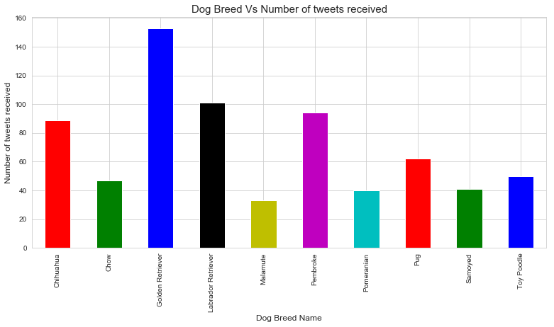

```python
# shows the top 10 represented dog breeds in the dataset
my_colors = ['r', 'g', 'b', 'k', 'y', 'm', 'c']
print(twitter_archive_master['dog_breed'].value_counts().nlargest(10))
twitter_archive_master['dog_breed'].value_counts().nlargest(10).sort_index()\
.plot(kind='bar',figsize=(13,6),color=my_colors);

#set the labels and titles of the plot.
plt.xlabel('Dog Breed Name',fontsize=12)
plt.ylabel('Number of tweets received',fontsize=12)
plt.title('Dog Breed Vs Number of tweets received',fontsize=15);
```

> - golden retriever and Labrador retriever have the most WeRateDogs tweets with about 153 and 101 tweets, respectively.

#### Which Dog breed received more likes in WeRateDogs Twitter feed?

```
dog_breed
Golden Retriever             1827130
Labrador Retriever           1152822
Pembroke                     1005221
Chihuahua                     707323
French Bulldog                582712
Samoyed                       536368
Chow                          431203
Cocker Spaniel                393648
Pug                           363652
Malamute                      339760
Toy Poodle                    319282
Chesapeake Bay Retriever      296334
Pomeranian                    287000
Eskimo Dog                    271620
Cardigan                      255694
German Shepherd               206136
Lakeland Terrier              205142
Basset                        190295
Miniature Pinscher            188632
Staffordshire Bullterrier     179855
Name: tweet_likes_count, dtype: int64
```

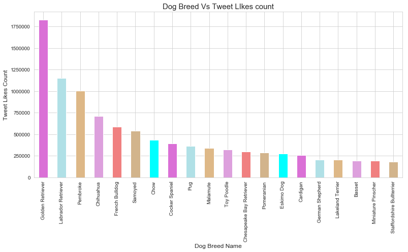

```python
co=['orchid','powderblue','burlywood','plum','lightcoral','tan','aqua']
print(twitter_archive_master.groupby('dog_breed')['tweet_likes_count'].sum().nlargest(20))
twitter_archive_master.groupby('dog_breed')['tweet_likes_count'].sum().nlargest(20).plot(kind='bar',figsize=(13,6),color=co);

#set the labels and titles of the plot.
plt.xlabel('Dog Breed Name',fontsize=12)
plt.ylabel('Tweet Likes Count',fontsize=12)
plt.title('Dog Breed Vs Tweet LIkes count',fontsize=15);
```

> - From the above chart and plot, we clearly seeing that the "Golden Retriever" received more number of tweet likes compare to other breeds

#### Top 10 common dog names

```
dog_name
Cooper     10
Lucy       10
Charlie     9
Oliver      9
Tucker      9
Penny       8
Daisy       7
Sadie       7
Winston     7
Jax         6
Name: tweet_id, dtype: int64
```

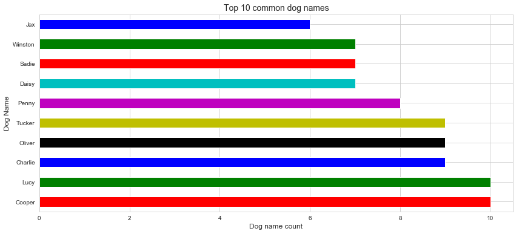

```python
print(twitter_archive_master.query('dog_name != "None"').groupby('dog_name').count()['tweet_id'].nlargest(10))
twitter_archive_master.query('dog_name != "None"').groupby('dog_name')\
.count()['tweet_id'].nlargest(10).plot(kind='barh',figsize = (14,6),color=my_colors);

#set the labels and titles of the plot.
plt.xlabel('Dog name count',fontsize=12)
plt.ylabel('Dog Name',fontsize=12)
plt.title('Top 10 common dog names',fontsize=14);
```

> - Most common dog name is showing as "cooper","Lucy","Charlie"

#### Most used tweet source

```
iPhone       1613
Twitter        22
TweetDeck       8
Name: tweet_source, dtype: int64
```

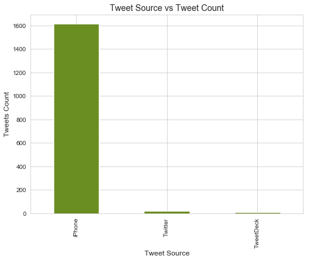

```python
print(twitter_archive_master['tweet_source'].value_counts())
twitter_archive_master['tweet_source'].value_counts().plot(kind='bar',figsize=(8,6),color='olivedrab');

#set the labels and titles of the plot.
plt.xlabel('Tweet Source',fontsize=12)
plt.ylabel('Tweets Count',fontsize=12)
plt.title('Tweet Source vs Tweet Count',fontsize=14);
```

> - We can see that the most of the tweets from iPhone twitter app, which is 98% in the total. Other twitter source is very very less.

###### Famous dog Stages

```
pupper     165
doggo       54
puppo       21
floofer      7
Name: dog_stage, dtype: int64
```

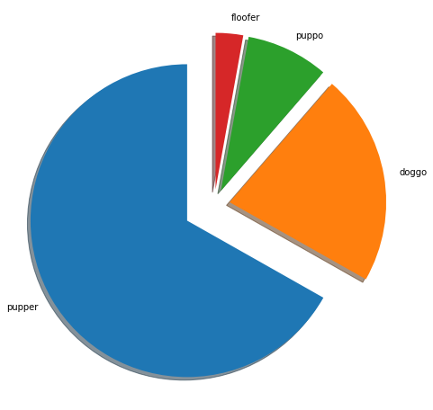

```python
#https://medium.com/@kvnamipara/a-better-visualisation-of-pie-charts-by-matplotlib-935b7667d77f
print(twitter_archive_master.query('dog_stage!= "None"')['dog_stage'].value_counts().iloc[0:4])
explode = (0.2, 0.1, 0.1, 0.1)
twitter_archive_master.query('dog_stage!= "None"')['dog_stage'].value_counts().iloc[0:4]\
.plot(kind='pie',explode=explode,figsize=(8,8),shadow = True,startangle = 90)
plt.ylabel("");
```

> - The pie chart is showing as "pupper" is the most popular doggolingo word used in WeRateDogs Tweet page.

###### WeRateDogs tweeting trend over time

```
tweet_date  tweet_date
2015        11            224
            12            279
2016        1             136
            2              91
            3             102
            4              48
            5              48
            6              67
            7              76
            8              47
            9              56
            10             59
            11             44
            12             51
2017        1              58
            2              60
            3              42
            4              33
            5              35
            6              40
            7              46
            8               1
Name: tweet_id, dtype: int64
```

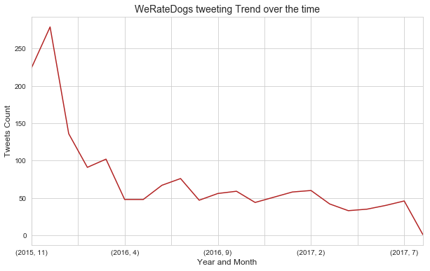

```python
print(twitter_archive_master.groupby([twitter_archive_master["tweet_date"].dt.year\
                                ,twitter_archive_master["tweet_date"].dt.month]).count()['tweet_id'])
twitter_archive_master.groupby([twitter_archive_master['tweet_date'].dt.year\
                               ,twitter_archive_master['tweet_date'].dt.month])\
                               .count()['tweet_id'].plot(figsize=(10,6),color='firebrick');

#set the labels and titles of the plot.
plt.xlabel('Year and Month',fontsize=12)
plt.ylabel('Tweets Count',fontsize=12)
plt.title('WeRateDogs tweeting Trend over the time',fontsize=14);
```

> - From the above plot, the twitter page started on 2015 and that time tweeting counts are more compare to recent. Looks like the tweeting activity got reduced drastically

###### Scatter plot relationship between 'tweets likes count' and 'retweets count'

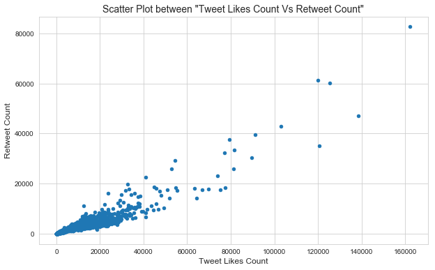

```python
twitter_archive_master.plot(x='tweet_likes_count',y='retweets_count',kind='scatter',figsize=(10,6));

#set the labels and titles of the plot.
plt.xlabel('Tweet Likes Count',fontsize=12)
plt.ylabel('Retweet Count',fontsize=12)
plt.title('Scatter Plot between "Tweet Likes Count Vs Retweet Count"',fontsize=14);
```

> - From the above plot, there is a positive correlation between "tweet likes count" and "Retweets count". People who favorite seem to almost always retweet

###### Average Retweeting and tweet Likes count trend over time

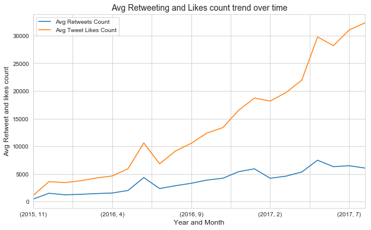

```python
twitter_archive_master.groupby([twitter_archive_master['tweet_date'].dt.year\
                                ,twitter_archive_master['tweet_date'].dt.month])\
                                .mean()['retweets_count'].plot(figsize=(10,6),label='Avg Retweets Count');
twitter_archive_master.groupby([twitter_archive_master['tweet_date'].dt.year\
                               ,twitter_archive_master['tweet_date'].dt.month])\
                                .mean()['tweet_likes_count'].plot(figsize=(10,6),label='Avg Tweet Likes Count');

#set the labels and titles of the plot.
plt.xlabel('Year and Month',fontsize=12)
plt.ylabel('Avg Retweet and likes count',fontsize=12)
plt.title('Avg Retweeting and Likes count trend over time',fontsize=14)
plt.legend();
```

> - The above plot shows the "average retweets count" and "Average tweet likes count" increasing since 2015. But if we compare with both, then the "tweet likes count" is higher increase with time.

###### Which weekday did people tweet most?

```
tweet_date
Saturday     205
Sunday       216
Friday       233
Wednesday    234
Thursday     239
Tuesday      239
Monday       277
Name: tweet_id, dtype: int64
```

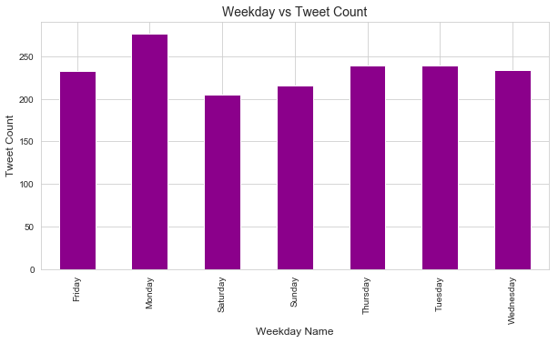

```python
print(twitter_archive_master.groupby(twitter_archive_master['tweet_date'].dt.weekday_name).count()['tweet_id'].sort_values())
twitter_archive_master.groupby(twitter_archive_master['tweet_date'].dt.weekday_name)\
.count()['tweet_id'].plot(kind='bar',figsize=(10,5),color='darkmagenta');

#set the labels and titles of the plot.
plt.xlabel('Weekday Name',fontsize=12)
plt.ylabel('Tweet Count',fontsize=12)
plt.title('Weekday vs Tweet Count',fontsize=14);
```

> - The above bar chart clearly showing as that the most number of people tweeted on Monday and Least tweeting on Saturday, Sunday

## Conclusions

- Labrador_retriever doggo swimming and standing in pool got max retweets and tweet likes
- "Golden Retriever" dog breed received more number of tweet likes compare to other breeds
- Most common dog name is showing as "cooper","Lucy","Charlie"
- "pupper" is the most popular doggolingo word used in WeRateDogs Tweet page.
- We can see that the most of the tweets from iPhone twitter app, which is 98% in the total. Other twitter source is very very less.
- WeRateDogs page started on 2015 and that time tweeting counts are more compare to recent. Looks like the tweeting activity got reduced drastically
- correlation map shows if the count of retweet is high the count of favorites go high
- "average retweets count" and "Average tweet likes count" increasing since 2015. But if we compare with both, then the "tweet likes count" is higher increase with time.
- The most number of people tweeted on Monday and Least tweeting on Saturday, sunday

## Resources I used in my analysis

- https://stackoverflow.com/questions/35465557/how-to-apply-color-in-markdown
- https://stackoverflow.com/questions/47022070/display-all-dataframe-columns-in-a-jupyter-python-notebook
- https://stackoverflow.com/questions/49888173/python-jupyter-notebook-print-dataframe-borders/51858584
- https://stackoverflow.com/questions/14875248/python-numpy-sort-array/24996734
- https://stackoverflow.com/questions/16176996/keep-only-date-part-when-using-pandas-to-datetime
- https://docs.python.org/3/howto/regex.html
- https://davidhamann.de/2017/06/26/pandas-select-elements-by-string/
- https://pandas.pydata.org/pandas-docs/stable/reference/api/pandas.DataFrame.loc.html
- https://pandas.pydata.org/pandas-docs/stable/user_guide/merging.html
- https://medium.com/@kvnamipara/a-better-visualisation-of-pie-charts-by-matplotlib-935b7667d77f
- https://pandas.pydata.org/pandas-docs/stable/reference/api/pandas.DataFrame.reindex.html
- https://github.com/jupyter/notebook/issues/2790